Autor: Martín de las Heras

# Práctica 3

### Ejercicio 1

Se descargan los datos diarios de la empresa del IBEX35 asignada según lista adjunta. El periodo es 2020-Mayo-4 (Lunes) a 2023-Noviembre-10 (Viernes) y las variables son precio mínimo, precio máximo, precio de apertura, precio de cierre y volumen negociado.

Nuestro objetivo es “aplicar modelos de regresión de ML-AS para predecir los valores de esas variables el lunes 13 de Noviembre, así como los 4 días siguientes. Consideramos tres opciones para los conjuntos de entrenamiento (TR) y de test (TS):

| Opción | TR-inicio | TR-fin | TS-inicio | TS-fin |
| --- | --- | --- | --- | --- |
| A | 2020-Mayo-4 | 2023-Enero-31 | 2023-Febrero-1 | 2023-Noviembre-10 |
| B | 2020-Mayo-4 | 2023-Agosto-31 | 2023-Septiembre-1 | 2023-Noviembre-10 |
| C | 2020-Mayo-4 | 2022-Agosto-31 | 2022-Septiembre-1 | 2023-Noviembre-10 |

En primer lugar, importamos las librerías que vamos a utilizar:

```python
import pandas as pd
import matplotlib.pyplot as plt
from statsmodels.tsa.ar_model import AutoReg
import statsmodels.api as sm
import seaborn as sns
from sklearn.metrics import mean_squared_error
from sklearn.preprocessing import PolynomialFeatures
import numpy as np
from sklearn.metrics import r2_score
```

A continuación, leemos los datos del fichero csv de la empresa

```python
df_acs = pd.read_csv('Datos históricos ACS.csv', index_col='Fecha', date_format='%d.%m.%Y', decimal=',')
df_acs['Vol.'] = df_acs['Vol.'].str.replace(',', '.')
df_acs['Vol.'] = (df_acs['Vol.'].replace(r'[KM]+$', '', regex=True).astype(float) * \
    df_acs['Vol.'].str.extract(r'[\d\.]+([KM]+)', expand=False)
    .fillna(1)
    .replace(['K','M'], [10**3, 10**6]).astype(int))
df_acs['% var.'] = df_acs['% var.'].str.replace(',','.')
df_acs['% var.'] = df_acs['% var.'].str.replace('%','')
df_acs['% var.'] = df_acs['% var.'].astype(float)/100.
df_acs.sort_values(by='Fecha', inplace=True)
df_acs = df_acs.asfreq(freq='B', method='ffill')
df_acs
```

| Fecha | Último | Apertura | Máximo | Mínimo | Vol. | % var. |
| --- | --- | --- | --- | --- | --- | --- |
| 2020-05-04 | 22.33 | 22.32 | 22.67 | 21.92 | 1960000.0 | -0.0193 |
| 2020-05-05 | 23.01 | 22.80 | 23.12 | 22.25 | 2040000.0 | 0.0305 |
| 2020-05-06 | 23.33 | 22.91 | 23.70 | 22.61 | 2470000.0 | 0.0139 |
| 2020-05-07 | 23.42 | 23.40 | 23.66 | 23.38 | 1250000.0 | 0.0039 |
| 2020-05-08 | 23.74 | 23.70 | 23.95 | 23.54 | 1230000.0 | 0.0137 |
| ... | ... | ... | ... | ... | ... | ... |
| 2023-11-06 | 33.50 | 33.89 | 33.89 | 33.39 | 270000.0 | -0.0115 |
| 2023-11-07 | 33.18 | 33.30 | 33.47 | 33.10 | 254900.0 | -0.0096 |
| 2023-11-08 | 33.26 | 33.09 | 33.30 | 32.93 | 663930.0 | 0.0024 |
| 2023-11-09 | 33.32 | 33.25 | 33.44 | 33.10 | 273070.0 | 0.0018 |
| 2023-11-10 | 33.26 | 33.22 | 33.47 | 33.16 | 231270.0 | -0.0018 |

920 rows × 6 columns

**a)** Calcula el porcentaje de datos utilizados en cada opción para TR y TS.

En primer lugar creamos los datasets de cada opción, tanto las **X** como las **y** de TR y TS:

```python
train_a = df_acs[df_acs.index <= '31.01.2023']
test_a = df_acs[df_acs.index > '31.01.2023']
train_b = df_acs[df_acs.index <= '31.08.2023']
test_b = df_acs[df_acs.index > '31.08.2023']
train_c = df_acs[df_acs.index <= '31.08.2022']
test_c = df_acs[df_acs.index > '31.08.2022']

X_train_a = train_a.drop(['% var.'], axis=1)
X_test_a = test_a.drop(['% var.'], axis=1)
X_train_b = train_b.drop(['% var.'], axis=1)
X_test_b = test_b.drop(['% var.'], axis=1)
X_train_c = train_c.drop(['% var.'], axis=1)
X_test_c = test_c.drop(['% var.'], axis=1)

y_train_a = train_a['% var.']
y_test_a = test_a['% var.']
y_train_b = train_b['% var.']
y_test_b = test_b['% var.']
y_train_c = train_c['% var.']
y_test_c = test_c['% var.']
```

A continuación, sacamos los porcentajes de cada una de las opciones para train y test.

```python
train_a_pct = X_train_a.shape[0]/df_acs.shape[0]
test_a_pct = X_test_a.shape[0]/df_acs.shape[0]
train_b_pct = X_train_b.shape[0]/df_acs.shape[0]
test_b_pct = X_test_b.shape[0]/df_acs.shape[0]
train_c_pct = X_train_c.shape[0]/df_acs.shape[0]
test_c_pct = X_test_c.shape[0]/df_acs.shape[0]

print(train_a_pct)
print(test_a_pct)
print(train_b_pct)
print(test_b_pct)
print(train_c_pct)
print(test_c_pct)
```

```
0.7793478260869565
0.22065217391304348
0.9445652173913044
0.05543478260869565
0.6608695652173913
0.3391304347826087
```

De esta manera nos quedan estos porcentajes para cada opción

| Opción | TR | TS |
| --- | --- | --- |
| A | 0.78 | 0.22 |
| B | 0.94 | 0.06 |
| C | 0.66 | 0.34 |

**b)** Muestra gráficamente las tres opciones en un gráfico de serie temporal para el precio de cierre.

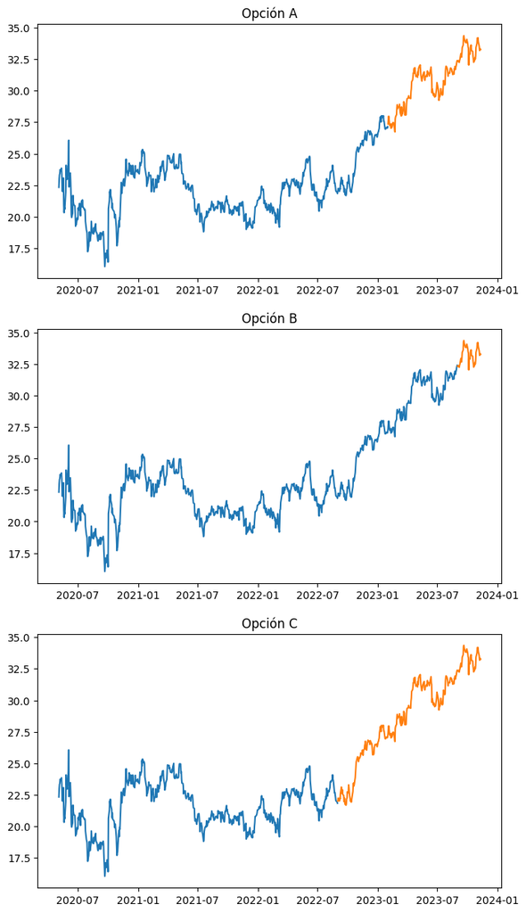

```python
plt.figure(figsize=(8,15))
plt.subplot(3,1,1)
plt.plot(X_train_a['Último'])
plt.plot(X_test_a['Último'])
plt.title('Opción A')
plt.subplot(3,1,2)
plt.plot(X_train_b['Último'])
plt.plot(X_test_b['Último'])
plt.title('Opción B')
plt.subplot(3,1,3)
plt.plot(X_train_c['Último'])
plt.plot(X_test_c['Último'])
plt.title('Opción C');
```

Aquí podemos ver que la opción **B** es la que tiene el menor tamaño del conjunto de test, así como la opción **C** es la que mayor tamaño tiene.

**c)** ¿En qué opción los periodos TR y TS son más diferentes? ¿Y más semejantes? En ambos casos respecto al precio de cierre. Emplea medidas estadísticas y gráficos como el gráfico de cajas.

Comparaos la media y varianza de los valores de cierre de los datos de train contra los de test:

```python
print('Opción A')
print('Media TR A: %s\nVarianza TR A: %s' % (X_train_a['Último'].mean(), X_train_a['Último'].std()))
print('Media TS A: %s\nVarianza TS A: %s' % (X_test_a['Último'].mean(), X_test_a['Último'].std()))
print('Opción B')
print('Media TR B: %s\nVarianza TR B: %s' % (X_train_b['Último'].mean(), X_train_b['Último'].std()))
print('Media TS B: %s\nVarianza TS B: %s' % (X_test_b['Último'].mean(), X_test_b['Último'].std()))
print('Opción C')
print('Media TR C: %s\nVarianza TR C: %s' % (X_train_c['Último'].mean(), X_train_c['Último'].std()))
print('Media TS C: %s\nVarianza TS C: %s' % (X_test_c['Último'].mean(), X_test_c['Último'].std()))
```

```
Opción A
Media TR A: 22.15100139470014
Varianza TR A: 2.2288990289564414
Media TS A: 30.887911330049267
Varianza TS A: 1.9158360484070511
Opción B
Media TR B: 23.541477560414272
Varianza TR B: 3.6914550174825735
Media TS B: 33.23470588235294
Varianza TS B: 0.6436034584778939
Opción C
Media TR C: 21.627769736842104
Varianza TR C: 1.8220367813408005
Media TS C: 28.855224358974358
Varianza TS C: 3.397229928077857
```

Aquí podemos ver que la media en las opciones **A** y **B** es muy distinta entre TR y TS. En la opción **A** tenemos que las varianzas son relativamente parecidas, al contrario que en la opción **B**.

La opción que parece que tiene parámetros más estables es la **C**.

Continuamos con el gráfico de cajas:

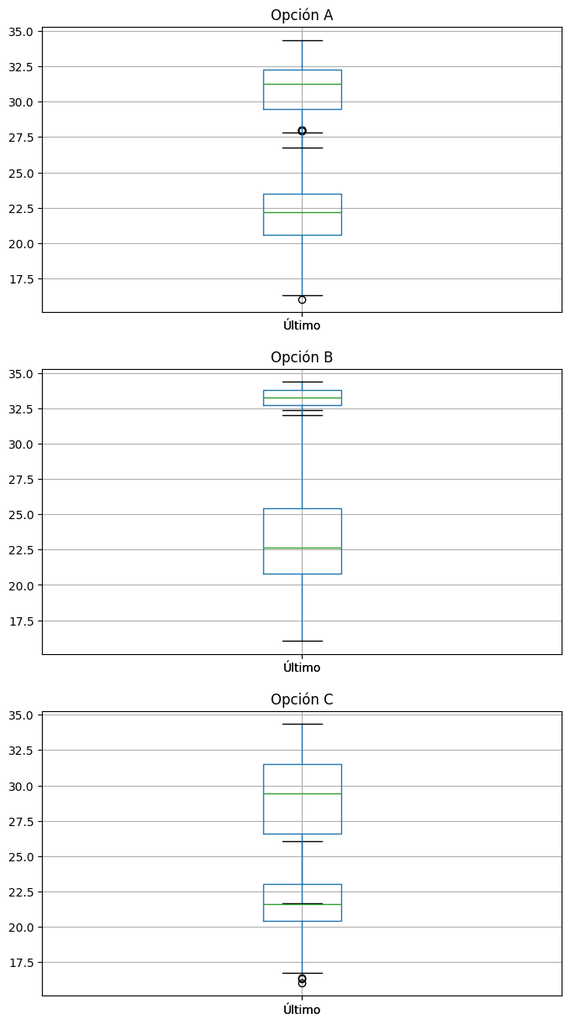

```python
plt.figure(figsize=(8,15))
plt.subplot(3,1,1)
X_train_a.boxplot(column=['Último'])
X_test_a.boxplot(column=['Último'])
plt.title('Opción A')
plt.subplot(3,1,2)
X_train_b.boxplot(column=['Último'])
X_test_b.boxplot(column=['Último'])
plt.title('Opción B')
plt.subplot(3,1,3)
X_train_c.boxplot(column=['Último'])
X_test_c.boxplot(column=['Último'])
plt.title('Opción C');
```

Aquí podemos ver en los diagramas de cajas las comparaciones entre las opciones **A**, **B** y **C**, donde podemos verificar lo dicho con los valores de la media y la varianza.

**d)** En qué opción los periodos TR y TS son más diferentes? ¿Y más semejantes? En ambos casos respecto a la variación diaria del precio de cierre. Emplea medidas estadísticas y gráficos como el gráfico de cajas.

Comparamos la media y la varianza de la columna *% var.* y graficamos los resultados en un diagrama de cajas.

```python
print('Opción A')
print('Media TR A: %s\nVarianza TR A: %s' % (y_train_a.mean(), y_train_a.std()))
print('Media TS A: %s\nVarianza TS A: %s' % (y_test_a.mean(), y_test_a.std()))
print('Opción B')
print('Media TR B: %s\nVarianza TR B: %s' % (y_train_b.mean(), y_train_b.std()))
print('Media TS B: %s\nVarianza TS B: %s' % (y_test_b.mean(), y_test_b.std()))
print('Opción C')
print('Media TR C: %s\nVarianza TR C: %s' % (y_train_c.mean(), y_train_c.std()))
print('Media TS C: %s\nVarianza TS C: %s' % (y_test_c.mean(), y_test_c.std()))
```

```
Opción A
Media TR A: 0.000520781032078103
Varianza TR A: 0.022581729289696997
Media TS A: 0.0010167487684729062
Varianza TS A: 0.010863938679622142
Opción B
Media TR B: 0.0006336018411967776
Varianza TR B: 0.0210193738486367
Media TS B: 0.0005725490196078428
Varianza TS B: 0.010486468965888805
Opción C
Media TR C: 0.00023404605263157888
Varianza TR C: 0.02405586870573025
Media TS C: 0.0014022435897435895
Varianza TS C: 0.010973518024954906
```

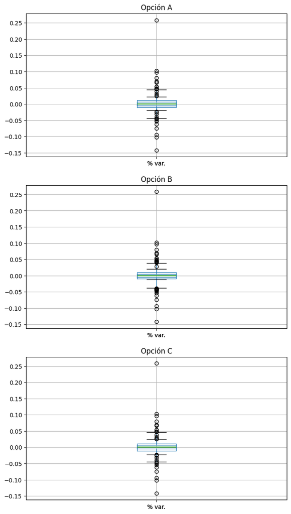

```python
plt.figure(figsize=(8,15))
plt.subplot(3,1,1)
pd.DataFrame(y_train_a).boxplot(column='% var.')
pd.DataFrame(y_test_a).boxplot(column='% var.')
plt.title('Opción A')
plt.subplot(3,1,2)
pd.DataFrame(y_train_b).boxplot(column='% var.')
pd.DataFrame(y_test_b).boxplot(column='% var.')
plt.title('Opción B')
plt.subplot(3,1,3)
pd.DataFrame(y_train_c).boxplot(column='% var.')
pd.DataFrame(y_test_c).boxplot(column='% var.')
plt.title('Opción C');
```

En este caso conviene mirarlo mejor por los valores que por la gráfica ya que por temas de la escala no se aprecian bien las diferencias entre los valores.

La relación del precio (variación) en un día con el precio (variación) en el día anterior se podría aprender y supervisar o modelar por la regresión lineal, a través del llamado modelo autorregresivo de orden 1 y notado por AR(1).

**e)** Dibuja el diagrama de dispersión con la recta de regresión ajustada para los precios de cierre con el modelo AR(1) en la opción A. Idem tomando todo el conjunto de datos como TR. Extraer conclusiones.

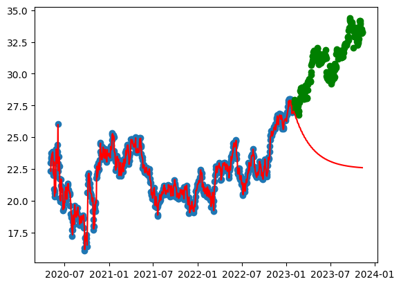

```python
ar_model_train = AutoReg(X_train_a['Último'], lags=1).fit()
pred_train = ar_model_train.predict(start=df_acs.index.min(), end=df_acs.index.max())

plt.plot(pred_train, color='red')
plt.scatter(X_train_a.index, X_train_a['Último'])
plt.scatter(X_test_a.index, X_test_a['Último'], color='green');
```

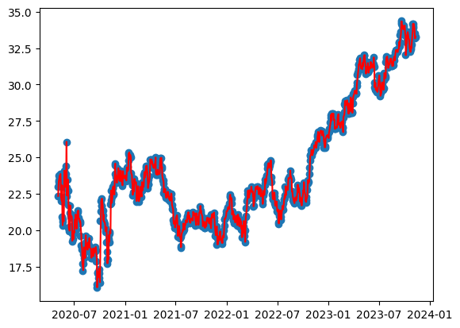

```python
ar_model_whole = AutoReg(df_acs['Último'], lags=1).fit()
pred_whole = ar_model_whole.predict(start=df_acs.index.min(), end=df_acs.index.max())

plt.plot(pred_whole, color='red')
plt.scatter(df_acs.index, df_acs['Último']);
```

Al haber una subida inesperadamente larga, el modelo que está solo entrenado con los datos de entrenamiento se espera una bajada, por lo que la predicción es mala. Sin embargo, el modelo entrenado con todos los datos encaja bien todos los datos de entrenamiento.

**f)** Obtener los residuos y proceder a un análisis gráfico de los mismos en las dos hipótesis de **e)**. Extraer conclusiones sobre el modelo AS-RLS basado en normalidad, aleatoriedad y homocedasticidad de los errores.

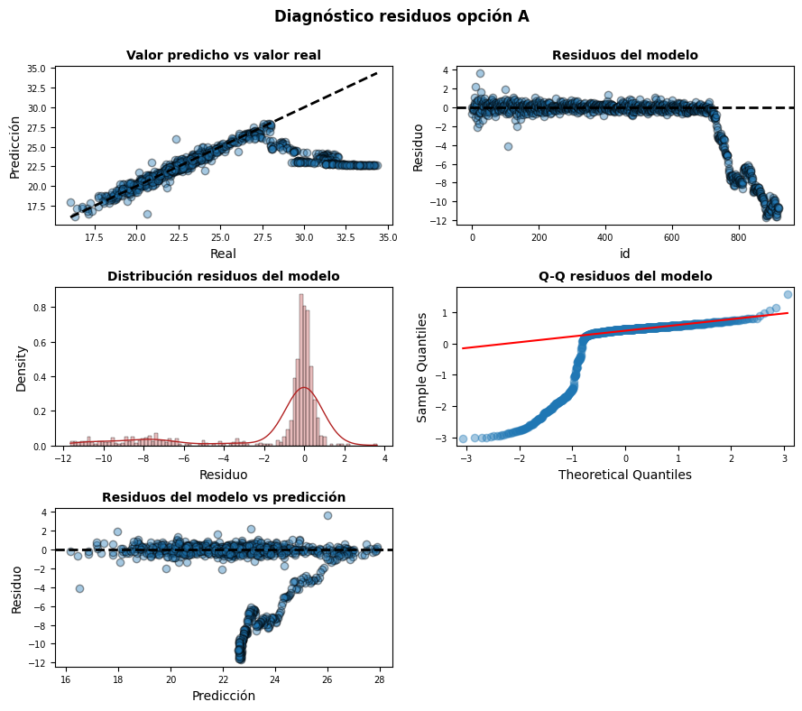

```python
# Diagnóstico errores (residuos) de las predicciones de entrenamiento
# ==============================================================================
pred_train.iloc[0] = pred_train.iloc[1]
residuos_train   = pred_train - df_acs['Último']

# Gráficos
# ==============================================================================
fig, axes = plt.subplots(nrows=3, ncols=2, figsize=(9, 8))

axes[0, 0].scatter(df_acs['Último'], pred_train, edgecolors=(0, 0, 0), alpha = 0.4)
axes[0, 0].plot([min(df_acs['Último']), max(df_acs['Último'])], [min(df_acs['Último']), max(df_acs['Último'])],
                'k--', lw=2)
axes[0, 0].set_title('Valor predicho vs valor real', fontsize = 10, fontweight = "bold")
axes[0, 0].set_xlabel('Real')
axes[0, 0].set_ylabel('Predicción')
axes[0, 0].tick_params(labelsize = 7)

axes[0, 1].scatter(list(range(len(df_acs['Último']))), residuos_train,
                   edgecolors=(0, 0, 0), alpha = 0.4)
axes[0, 1].axhline(y = 0, linestyle = '--', color = 'black', lw=2)
axes[0, 1].set_title('Residuos del modelo', fontsize = 10, fontweight = "bold")
axes[0, 1].set_xlabel('id')
axes[0, 1].set_ylabel('Residuo')
axes[0, 1].tick_params(labelsize = 7)

sns.histplot(
    data    = residuos_train,
    stat    = "density",
    kde     = True,
    line_kws= {'linewidth': 1},
    color   = "firebrick",
    alpha   = 0.3,
    ax      = axes[1, 0]
)

axes[1, 0].set_title('Distribución residuos del modelo', fontsize = 10,
                     fontweight = "bold")
axes[1, 0].set_xlabel("Residuo")
axes[1, 0].tick_params(labelsize = 7)


sm.qqplot(
    residuos_train,
    fit   = True,
    line  = 'q',
    ax    = axes[1, 1],
    color = 'firebrick',
    alpha = 0.4,
    lw    = 2
)
axes[1, 1].set_title('Q-Q residuos del modelo', fontsize = 10, fontweight = "bold")
axes[1, 1].tick_params(labelsize = 7)

axes[2, 0].scatter(pred_train, residuos_train,
                   edgecolors=(0, 0, 0), alpha = 0.4)
axes[2, 0].axhline(y = 0, linestyle = '--', color = 'black', lw=2)
axes[2, 0].set_title('Residuos del modelo vs predicción', fontsize = 10, fontweight = "bold")
axes[2, 0].set_xlabel('Predicción')
axes[2, 0].set_ylabel('Residuo')
axes[2, 0].tick_params(labelsize = 7)

# Se eliminan los axes vacíos
fig.delaxes(axes[2,1])

fig.tight_layout()
plt.subplots_adjust(top=0.9)
fig.suptitle('Diagnóstico residuos opción A', fontsize = 12, fontweight = "bold");
```

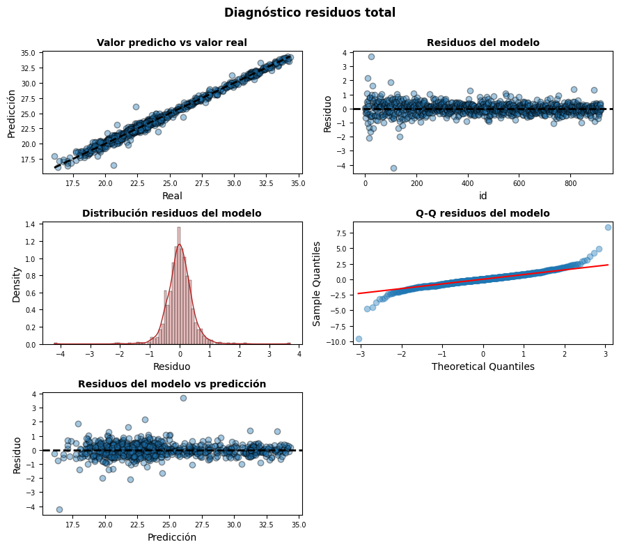

```python
# Diagnóstico errores (residuos) de las predicciones de entrenamiento
# ==============================================================================
pred_whole.iloc[0] = pred_whole.iloc[1]
residuos_train   = pred_whole - df_acs['Último']

# Gráficos
# ==============================================================================
fig, axes = plt.subplots(nrows=3, ncols=2, figsize=(9, 8))

axes[0, 0].scatter(df_acs['Último'], pred_whole, edgecolors=(0, 0, 0), alpha = 0.4)
axes[0, 0].plot([min(df_acs['Último']), max(df_acs['Último'])], [min(df_acs['Último']), max(df_acs['Último'])],
                'k--', lw=2)
axes[0, 0].set_title('Valor predicho vs valor real', fontsize = 10, fontweight = "bold")
axes[0, 0].set_xlabel('Real')
axes[0, 0].set_ylabel('Predicción')
axes[0, 0].tick_params(labelsize = 7)

axes[0, 1].scatter(list(range(len(df_acs['Último']))), residuos_train,
                   edgecolors=(0, 0, 0), alpha = 0.4)
axes[0, 1].axhline(y = 0, linestyle = '--', color = 'black', lw=2)
axes[0, 1].set_title('Residuos del modelo', fontsize = 10, fontweight = "bold")
axes[0, 1].set_xlabel('id')
axes[0, 1].set_ylabel('Residuo')
axes[0, 1].tick_params(labelsize = 7)

sns.histplot(
    data    = residuos_train,
    stat    = "density",
    kde     = True,
    line_kws= {'linewidth': 1},
    color   = "firebrick",
    alpha   = 0.3,
    ax      = axes[1, 0]
)

axes[1, 0].set_title('Distribución residuos del modelo', fontsize = 10,
                     fontweight = "bold")
axes[1, 0].set_xlabel("Residuo")
axes[1, 0].tick_params(labelsize = 7)


sm.qqplot(
    residuos_train,
    fit   = True,
    line  = 'q',
    ax    = axes[1, 1],
    color = 'firebrick',
    alpha = 0.4,
    lw    = 2
)
axes[1, 1].set_title('Q-Q residuos del modelo', fontsize = 10, fontweight = "bold")
axes[1, 1].tick_params(labelsize = 7)

axes[2, 0].scatter(pred_whole, residuos_train,
                   edgecolors=(0, 0, 0), alpha = 0.4)
axes[2, 0].axhline(y = 0, linestyle = '--', color = 'black', lw=2)
axes[2, 0].set_title('Residuos del modelo vs predicción', fontsize = 10, fontweight = "bold")
axes[2, 0].set_xlabel('Predicción')
axes[2, 0].set_ylabel('Residuo')
axes[2, 0].tick_params(labelsize = 7)

# Se eliminan los axes vacíos
fig.delaxes(axes[2,1])

fig.tight_layout()
plt.subplots_adjust(top=0.9)
fig.suptitle('Diagnóstico residuos total', fontsize = 12, fontweight = "bold");
```

En estos casos se puede observar lo que hemos comentado en el apartado anterior:

**g)** Comparar el MSE y R cuadrado en TR y TS en la opción **A**

```python
mse_train = mean_squared_error(X_train_a['Último'], pred_train.loc[:'31.01.2023'])
mse_test = mean_squared_error(X_test_a['Último'], pred_train.loc['02.01.2023':])

r2_train = X_train_a['Último'].corr(pred_train.loc[:'31.01.2023'])**2
r2_test = X_test_a['Último'].corr(pred_train.loc['02.01.2023':])**2

print('MSE TR: %f' % mse_train)
print('MSE TS: %f' % mse_test)

print('R2 TR: %f' % r2_train)
print('R2 TS: %f' % r2_test)
```

```
MSE TR: 0.217709
MSE TS: 60.905249
R2 TR: 0.956116
R2 TS: 0.723127
```

Claramente se puede ver que el error en TS es mucho más grande que en TR, y por otro lado que los valores de R2 también son mucho mejores para TR que para TS. Esto se corresponde con lo que hemos visto en el análisis de los errores y en las gráficas del AR.

**h)** ¿Qué información se puede obtener sobre la predicción del precio de cierre del lunes 13 de Noviembre a un 95 %?

Para ello tomamos el modelo que ha sido entrenado con todos los datos, ya que nos dará una mejor predicción.

```python
ar_model_whole.predict(start='13.11.2023', end='13.11.2023')
prediction = ar_model_whole.get_prediction(start='13.11.2023', end='13.11.2023')
prediction.predicted_mean
```

```
2023-11-13    33.244211
Freq: B, Name: predicted_mean, dtype: float64
```

Nos realiza la predicción de que el precio de cierre el lunes 13 de Noviembre será de 33.244211. Comprobamos ahora el intervalo de confianza que nos da para la predicción:

```python
prediction.conf_int(alpha=0.05)
```

|  | lower | upper |
| --- | --- | --- |
| 2023-11-13 | 32.378472 | 34.109951 |

### Ejercicio 2

A veces el precio de cierre (variación) diario se relaciona con el precio de cierre (variación) de varios días atrás. Si es con 2 días sería el modelo AR(2), si es con p días atrás sería el modelo AR(p).

**a)** Dibuja el gráfico matricial del precio de cierre de un día con el día anterior, dos días atrás,….y hasta 10 días atrás. Calcula la matriz de correlaciones. Extrae conclusiones sobre el “orden” del modelo AR.

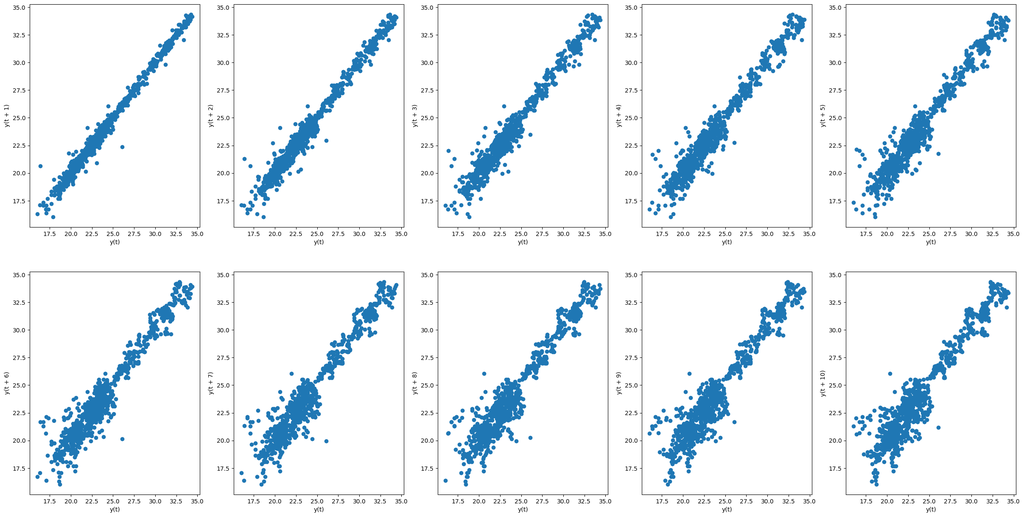

```python
from pandas.plotting import lag_plot
plt.figure(figsize=(30,15))
for i in range(10):
    plt.subplot(2,5,i+1)
    lag_plot(df_acs['Último'], lag=i+1)
```

**b)** Para responder al apartado anterior se utilizan los gráficos de autocorrelación y autocorrelación parcial. Obtenerlos para el precio de cierre. Como ayuda ver el video ACF & PACF Code Example : Time Series Talk

https://www.youtube.com/watch?v=y8opUEd05Dg

Sacamos el gráfico de autocorrelación parcial:

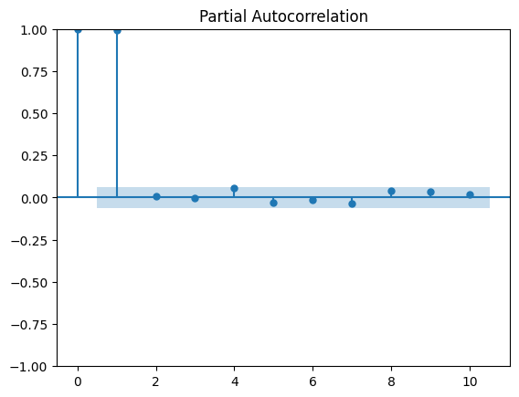

```python
from statsmodels.graphics.tsaplots import plot_pacf
pacf = plot_pacf(df_acs['Último'], lags=10)
```

**c)** Calcula de manera razonada el modelo AS-RLM del precio diario de cierre en función de los precios de cierre en los días anteriores. Es decir, el orden del modelo AR y la ecuación del modelo AR.

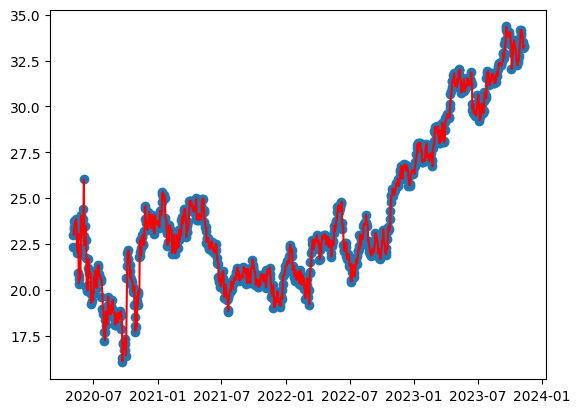

```python
ar_model_whole_2 = AutoReg(df_acs['Último'], lags=2).fit()
pred_whole = ar_model_whole_2.predict(start=df_acs.index.min(), end=df_acs.index.max())

plt.plot(pred_whole, color='red')
plt.scatter(df_acs.index, df_acs['Último']);
```

**d)** Comparar lo anterior con las indicaciones de la web https://dataaspirant.com/stepwise-regression/ para proporcionar el modelo AS-RLM con selección de variables autorregresivas que utilizarías en el futuro. Interpreta dicho modelo.

**e)** ¿Qué información se puede obtener sobre la predicción del precio de cierre del lunes 13 de Noviembre a un 95 % según la un modelo AS-RLM de tipo autoregresión o modelo AR?

```python
ar_model_whole_2.predict(start='13.11.2023', end='13.11.2023')
prediction = ar_model_whole_2.get_prediction(start='13.11.2023', end='13.11.2023')
prediction.predicted_mean
```

```
2023-11-13    33.246561
Freq: B, Name: predicted_mean, dtype: float64
```

Nos realiza la predicción de que el precio de cierre el lunes 13 de Noviembre será de 33.246561. Comprobamos ahora el intervalo de confianza que nos da para la predicción:

```python
prediction.conf_int(alpha=0.05)
```

|  | lower | upper |
| --- | --- | --- |
| 2023-11-13 | 32.381532 | 34.111589 |

### Ejercicio 3

Ahora nos planteamos establecer una relación polinómica entre el precio de cierre (variación) diario y el precio de cierre (variación) del día anterior. Para decidir el orden del polinomio a utilizar se puede consultar

https://rohanmandrekar.netlify.app/post/overfitting-using-higher-order-linear-regression/

**a)** Adjuntar los gráficos y salidas correspondientes para tomar la decisión anterior

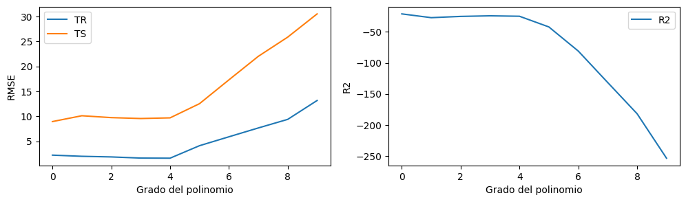

```python
batch_size=10
rmse_train = [None]*batch_size
rmse_test = [None]*batch_size
r2 = [None]*batch_size

X_train_a['DiasDesdeInicio'] = (X_train_a.index - X_train_a.index.min()).days
X_train = X_train_a['DiasDesdeInicio'].values.reshape(-1, 1)

X_test_a['DiasDesdeInicio'] = (X_test_a.index - X_test_a.index.min()).days
X_test = X_test_a['DiasDesdeInicio'].values.reshape(-1, 1)

for i in range(batch_size):
    polynomial_features= PolynomialFeatures(degree=i)
    xp_train = polynomial_features.fit_transform(X_train)

    modelo = sm.OLS(endog=X_train_a['Último'], exog=xp_train,).fit()

    xp_test = polynomial_features.fit_transform(X_test)
    predicciones_train = modelo.get_prediction(exog=xp_train).summary_frame(alpha=0.05)
    predicciones_test = modelo.get_prediction(exog=xp_test).summary_frame(alpha=0.05)
    rmse_train[i]=np.sqrt(mean_squared_error(X_train_a['Último'],predicciones_train['mean']))
    rmse_test[i]=np.sqrt(mean_squared_error(X_test_a['Último'],predicciones_test['mean']))
    r2[i]=r2_score(X_test_a['Último'],predicciones_test['mean'])

plt.figure(figsize=(12,3))
plt.subplot(1,2,1)
plt.plot(rmse_train, label='TR')
plt.plot(rmse_test, label='TS')
plt.xlabel('Grado del polinomio')
plt.ylabel('RMSE')
plt.legend()
plt.subplot(1,2,2)
plt.plot(r2, label='R2')
plt.xlabel('Grado del polinomio')
plt.ylabel('R2')
plt.legend();
```

**b)** ¿Qué información se puede obtener sobre la predicción del precio de cierre del lunes 13 de Noviembre a un 95 % según la regresión polinómica?

```
                            OLS Regression Results
==============================================================================
Dep. Variable:                 Último   R-squared:                       0.862
Model:                            OLS   Adj. R-squared:                  0.861
Method:                 Least Squares   F-statistic:                     1429.
Date:                Sat, 18 Nov 2023   Prob (F-statistic):               0.00
Time:                        19:24:32   Log-Likelihood:                -1718.7
No. Observations:                 920   AIC:                             3447.
Df Residuals:                     915   BIC:                             3471.
Df Model:                           4
Covariance Type:            nonrobust
==============================================================================
                 coef    std err          t      P>|t|      [0.025      0.975]
------------------------------------------------------------------------------
const         19.2000      0.255     75.155      0.000      18.699      19.701
x1             0.0331      0.003     11.971      0.000       0.028       0.038
x2            -0.0001   8.75e-06    -13.196      0.000      -0.000   -9.83e-05
x3          1.379e-07   1.02e-08     13.461      0.000    1.18e-07    1.58e-07
x4         -4.752e-11   3.95e-12    -12.018      0.000   -5.53e-11   -3.98e-11
==============================================================================
Omnibus:                       28.949   Durbin-Watson:                   0.079
Prob(Omnibus):                  0.000   Jarque-Bera (JB):               48.220
Skew:                          -0.248   Prob(JB):                     3.38e-11
Kurtosis:                       4.006   Cond. No.                     4.50e+12
==============================================================================

Notes:
[1] Standard Errors assume that the covariance matrix of the errors is correctly specified.
[2] The condition number is large, 4.5e+12. This might indicate that there are
strong multicollinearity or other numerical problems.
```

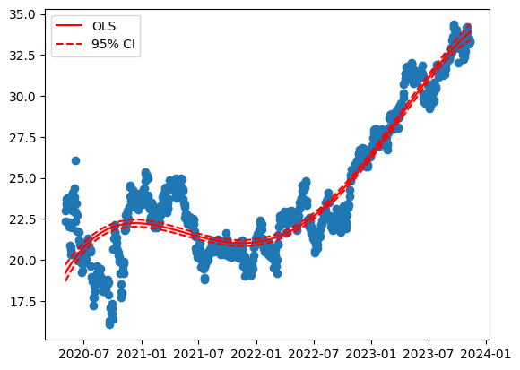

```python
polynomial_features = PolynomialFeatures(degree=4)
df_acs['DiasDesdeInicio'] = (df_acs.index - df_acs.index.min()).days
X = df_acs['DiasDesdeInicio'].values.reshape(-1, 1)
xp = polynomial_features.fit_transform(X)

modelo = sm.OLS(endog=df_acs['Último'], exog=xp,).fit()
print(modelo.summary())
xp = polynomial_features.fit_transform(np.append(X,max(X)+1).reshape(-1,1))
predicciones = modelo.get_prediction(exog=xp).summary_frame(alpha=0.05)
predicciones['x'] = np.append(df_acs.index.values,max(df_acs.index.values)+1)
predicciones = predicciones.sort_values('x')
modelo.conf_int(alpha=0.05)

plt.scatter(df_acs.index,df_acs['Último'])
plt.plot(predicciones['x'], predicciones["mean"], linestyle='-', label="OLS", color='red')
plt.plot(predicciones['x'], predicciones["mean_ci_lower"], linestyle='--', color='red', label="95% CI")
plt.plot(predicciones['x'], predicciones["mean_ci_upper"], linestyle='--', color='red')
plt.fill_between(predicciones['x'], predicciones["mean_ci_lower"], predicciones["mean_ci_upper"], alpha=0.1, color='red')
plt.legend();
```

```python
predicciones.iloc[-1]
```

```
mean                                 31.005065
mean_se                               0.105918
mean_ci_lower                        30.797197
mean_ci_upper                        31.212934
obs_ci_lower                         26.056063
obs_ci_upper                         35.954068
x                2023-11-10 00:00:00.000000001
Name: 920, dtype: object
```